# Geog533 Lab 8

### Question 2(g)

Graph the data and the regression line.

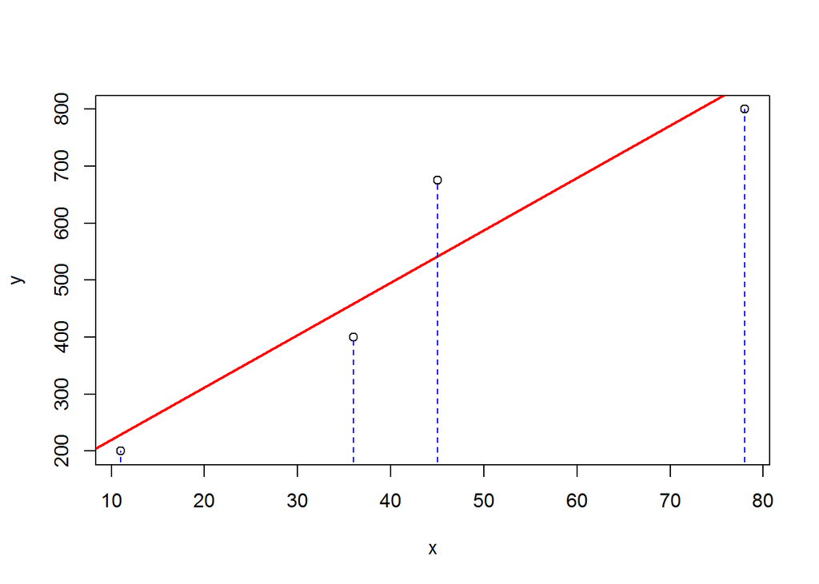

```r
plot(y~x)
abline(m,col='red',lwd=2)
segments(x,predicted,x,y,col='blue',lty="dashed")
```

## Question 3

This is Exercise 10 in Chapter 8 of the Textbook [R].

Use R and the [Milwaukee dataset](http://spatial.binghamton.edu/geog533/data/Milwaukee_Sales.csv) to:

### Problem

perform a regression using sales price as the dependent variable and lot size as the independent variable.

### Solution

```r
df <- read.csv("http://spatial.binghamton.edu/geog533/data/Milwaukee_Sales.csv")
x2 <- df$LotSize
y2 <- df$SalePrice
m <- lm(y2~x2)
summary(m)
```

```
##
## Call:
## lm(formula = y2 ~ x2)
##
## Residuals:
##     Min      1Q  Median      3Q     Max
## -144724  -42205  -14553   20987  808570
##
## Coefficients:
##              Estimate Std. Error t value Pr(>|t|)
## (Intercept) 9.298e+04  5.249e+03  17.715  < 2e-16 ***
## x2          6.443e+00  7.835e-01   8.223 4.37e-16 ***
## ---
## Signif. codes:  0 '***' 0.001 '**' 0.01 '*' 0.05 '.' 0.1 ' ' 1
##
## Residual standard error: 83090 on 1447 degrees of freedom
## Multiple R-squared:  0.04464,    Adjusted R-squared:  0.04398
## F-statistic: 67.62 on 1 and 1447 DF,  p-value: 4.374e-16
```

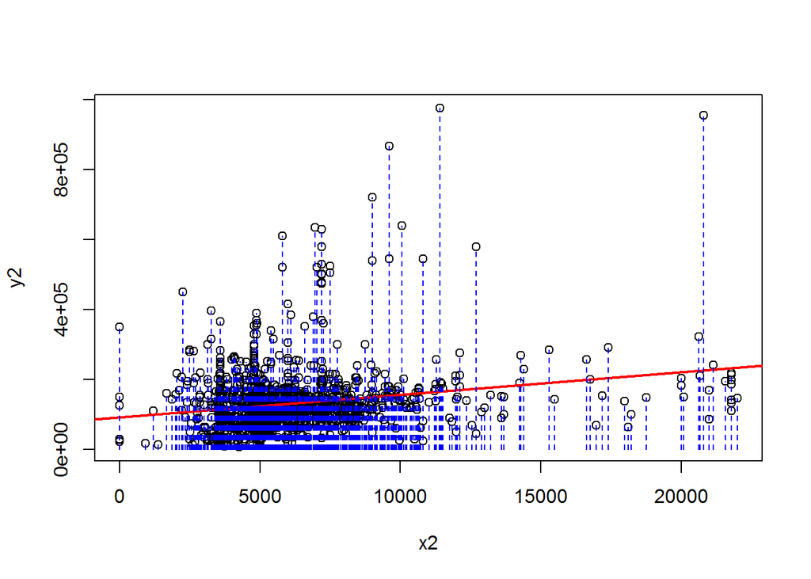

```r
perform <- plot(y2~x2)
abline(m,col='red',lwd=2)
segments(x2,predicted,x2,y2,col='blue',lty="dashed")
```

## Question 4

This is Exercise 11 in Chapter 8 of the Textbook [R].

Use R and the Hypothetical [UK Housing Prices dataset](http://spatial.binghamton.edu/geog533/data/UK_Housing.csv) to:

### Question 4(a)

perform a regression using house price as the dependent variable, and number of bedrooms as the independent variable;

```r
df <- read.csv("http://spatial.binghamton.edu/geog533/data/UK_Housing.csv")
x3 <- df$bedrooms
y3 <- df$price
m <- lm(y3~x3)
summary(m)
```

```
##
## Call:
## lm(formula = y3 ~ x3)
##
## Residuals:
##    Min     1Q Median     3Q    Max
## -39324 -11511  -3539   8461 107568
##
## Coefficients:
##             Estimate Std. Error t value Pr(>|t|)
## (Intercept)  11254.1     2312.7   4.866 1.53e-06 ***
## x3           11892.6      876.5  13.568  < 2e-16 ***
## ---
## Signif. codes:  0 '***' 0.001 '**' 0.01 '*' 0.05 '.' 0.1 ' ' 1
##
## Residual standard error: 17800 on 497 degrees of freedom
## Multiple R-squared:  0.2703, Adjusted R-squared:  0.2688
## F-statistic: 184.1 on 1 and 497 DF,  p-value: < 2.2e-16
```

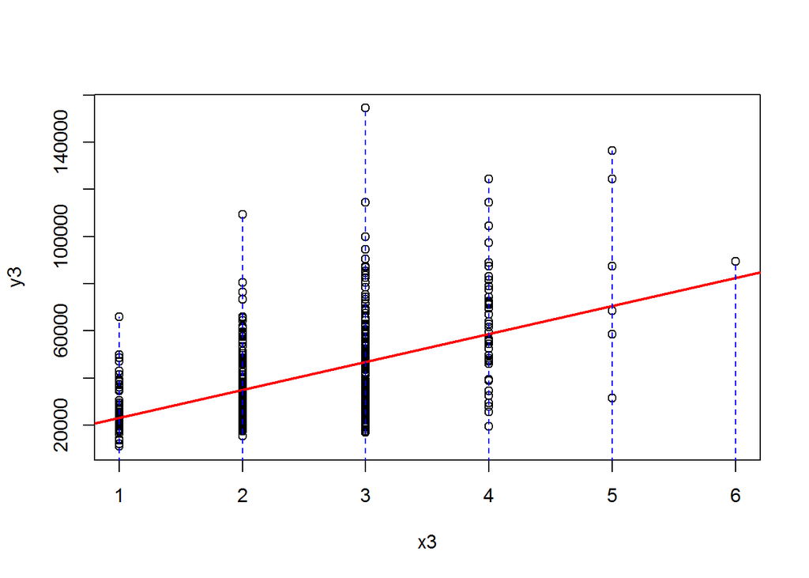

```r
perform2 <- plot(y3~x3)
abline(m,col='red',lwd=2)
segments(x3,predicted,x3,y3,col='blue',lty="dashed")
```

### Question 4(b)

2. repeat part (a), using the number of bathrooms as the independent variable, and comment on the results.

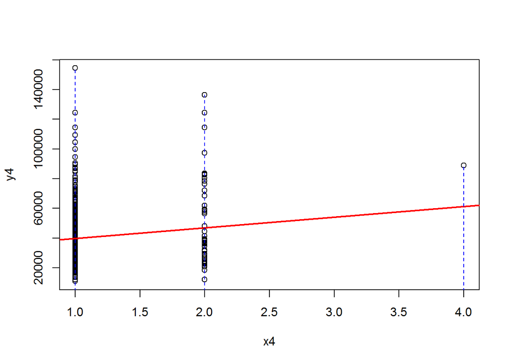

```r
df <- read.csv("http://spatial.binghamton.edu/geog533/data/UK_Housing.csv")
x4 <- df$bathrooms
y4 <- df$price
m <- lm(y4~x4)
perform3 <- plot(y4~x4)
abline(m,col='red',lwd=2)
segments(x4,predicted,x4,y4,col='blue',lty="dashed")
```

```r
#As housing prices increases, the number bedrooms and bathrooms increase.
```

## Question 5

Download the hometown.csv, append your name and hometown coordinates to the csv, then use [leaflet](https://rstudio.github.io/leaflet/) to create a web map (10 pt.)

```r
library(leaflet)
m <- leaflet()
m <- addTiles(m)
m <- addMarkers(m, lng=-73.7949, lat=41.1220, popup="Westchester County")
m
```

[interactive chart not shown]